# Ken-Behrenia House Price

Yu Heng Cheah

2022-06-06

## Exploratory Data Analysis

## Structure

Before conducting the Exploratory Data Analysis, the data set was split into a training data set and testing data set, where 75% of the rows were random sampling in the training data set and the remaining 25% were put into the test set.

Using str() function, we can find the structure of the training data set. The data set contains 30,000 observations and 15 variables.

For the testing data set, the data set contains 10,000 observation with 13 variables. The two missing variables were ‘price’ and ‘sent’, which we will be using the training data set to create models to predict the variables in the testing data set.

The data type for the variables id and sent is integer, price variable is numeric and the remaining variables are character. In order to continue with the exploration of the project, all variables with the type “character” are convert into “numeric” except the variables sent, year, built, reno, bedrooms, bathrooms and environ are convert into “factor”. This is because the variables are categorical nominal with categorical data input.

```r
str(train)
```

```
## 'data.frame':    30000 obs. of  15 variables:
##  $ id        : int  1 2 3 4 5 6 7 8 9 10 ...
##  $ price     : num  1.62 1.234 0.969 -0.156 -0.918 ...
##  $ sent      : int  1 1 1 0 0 1 1 1 0 0 ...
##  $ cond      : chr  "1.254" "2.626" "1.285" "2.521" ...
##  $ year      : chr  "5" "2" "9" "3" ...
##  $ built     : chr  "1" "2" "2" "2" ...
##  $ lat       : chr  "0.214292386167818" "1.04368478552843" "0.606694521912293" "0.196032855601255" ...
##  $ lon       : chr  "0.0870801669691538" "0.175831949918982" "0.0777294735788834" "0.104240128073335" ...
##  $ sq.m.h    : chr  "271" "400" "270" "130" ...
##  $ sq.m.block: chr  "1686" "805" "497" "446" ...
##  $ sq.m.pool : chr  "21" "0" "0" "0" ...
##  $ reno      : chr  "0" "0" "0" "0" ...
##  $ bedrooms  : chr  "3" "5" "2" "5" ...
##  $ bathrooms : chr  "3" "4" "3" "2" ...
##  $ environ   : chr  "1" "1" "1" "1" ...
```

```r
str(test)
```

```
## 'data.frame':    10000 obs. of  13 variables:
##  $ id        : int  21 23 26 27 30 33 35 45 49 50 ...
##  $ cond      : chr  "-0.663" "-0.215" "0.781" "0.029" ...
##  $ year      : chr  "10" "9" "2" "6" ...
##  $ built     : chr  "8" "3" "2" "8" ...
##  $ lat       : chr  "0.198934576106144" "1.12880388882484" "-3.16573946722443" "NA" ...
##  $ lon       : chr  "0.318718838529676" "0.143025189524979" "-4.05361948837381" "0.253234283710486" ...
##  $ sq.m.h    : chr  "379" "99" "298" "273" ...
##  $ sq.m.block: chr  "1031" "781" "1401" "920" ...
##  $ sq.m.pool : chr  "64" "0" "0" "82" ...
##  $ reno      : chr  "1" "0" "0" "0" ...
##  $ bedrooms  : chr  "NA" "2" "3" "5" ...
##  $ bathrooms : chr  "3" "1" "3" "4" ...
##  $ environ   : chr  "0" "3" "3" "1" ...
```

Before converting the data type, sent, year, built, reno, bedrooms, bathrooms and environ are convert to numeric first to fill in the missing values. After filling in the missing values we then can convert the data type to factor. We do the same steps for the testing data set.

## Plots

sq.m.h, sq.m.block, sq.m.pool are right-skewed by looking at the line plot, with mean to the right of the median.

lat and lon are left-skewed by looking at the line graph, with the mean to the left of the median. There could be an extreme value on lat.

Cond is approcimately normally distributed.

Year and built are comb distribution, this may be contributed because year and built are categorical nominal data.

Furthermore, reno, bedrooms, bathrooms and environ are multimodal distribution too due to the input are categorical nominal data.

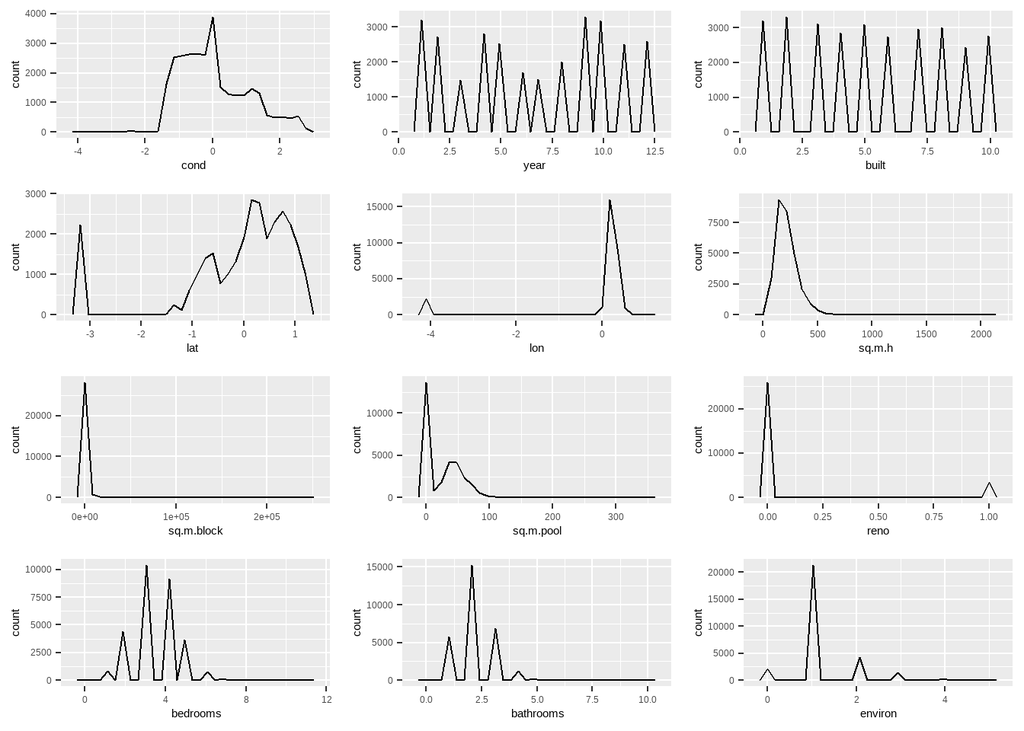

## Filling in missing values

For skewed covariates, such as lat, lon, sq.m.h, sq.m.block and sq.m.pool, median imputation is used tp replace missing values with the median. Due to the selected covariates are continuous variables that have skewed distributions, with median imputation, it can help to maintain the central tendency of the data.

Mode imputation is used for year, built, reno, bedrooms, bathrooms and environ. To justify my choice, I used mode imputation to preserve the category with the highest occurrence.

As the covariate, cond, is approximately normally distributed, mean imputation is used to replace the missing values with the mean of the data. For the remaining covariates, id, price, and sent do not have any missing values, so no imputation methods were used.

## Correlation and Relationship

There’s no positive nor negative correlation but there’s strong relationship between cond and price as data points are clustered tightly.

Looking at the box plot between cond and sent, we see that there’s an outlier where someone was very satisfied of the sale price after 6 months with a negative condition score. Inversely, there are some outliers with positive condition score that are not satisfied with the sale price. We also can tell that the worse the condition score, more people will not be satisfied with the sale price.

```r
coef(lm(price ~ cond, data = train))
```

```
## (Intercept)        cond
##  0.24332531  0.02399454
```

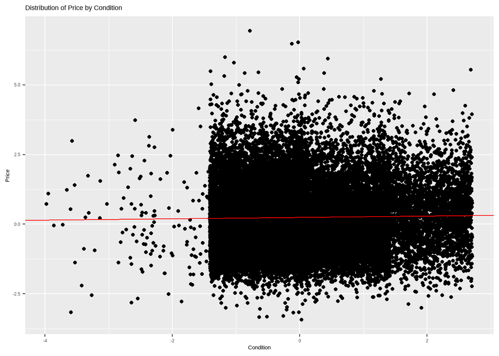

```r
ggplot(data = train) +
  geom_point(mapping = aes(x = cond, y = price)) + geom_abline(intercept = 0.24332531, slope = 0.02399454, col = "red") + ylab("Price") +xlab("Condition") + ggtitle("Distribution of Price by Condition")
```

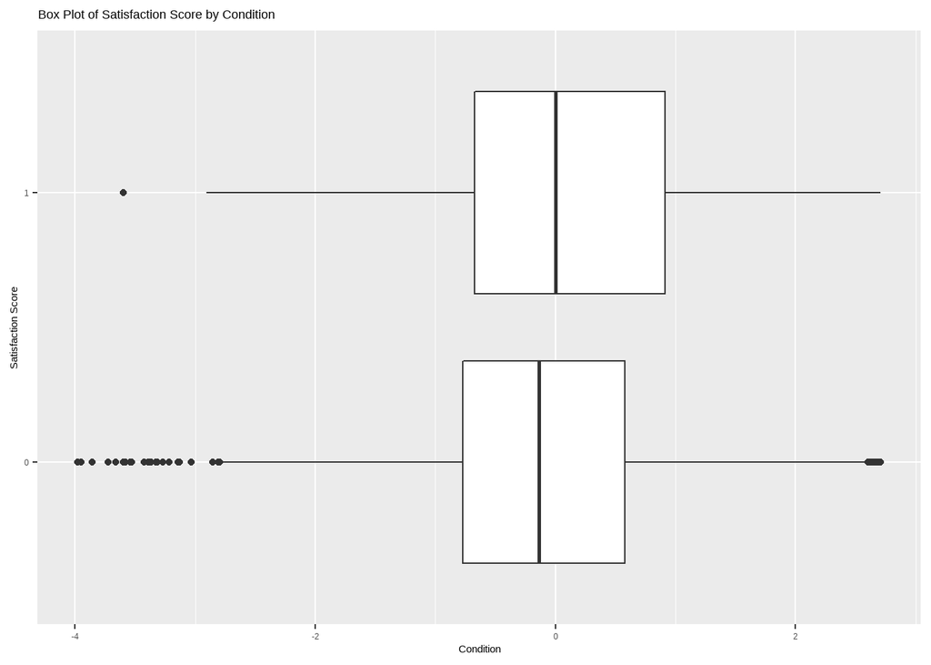

```r
ggplot(data = train, mapping = aes(x = cond, y = sent)) +
    geom_boxplot()+ ylab("Satisfaction Score") +xlab("Condition") + ggtitle("Box Plot of Satisfaction Score by Condition")
```

From the box plot below, we see that houses sold on year 2 and 3 have significant outliers having higher sold price.

From the tile plot, starting from houses sold on year 9 to year 12, we noticed that there were a significant amount of observations that are not satisfied. Overall, we noticed that there were more observations that were not satisfied compared to satisfied.

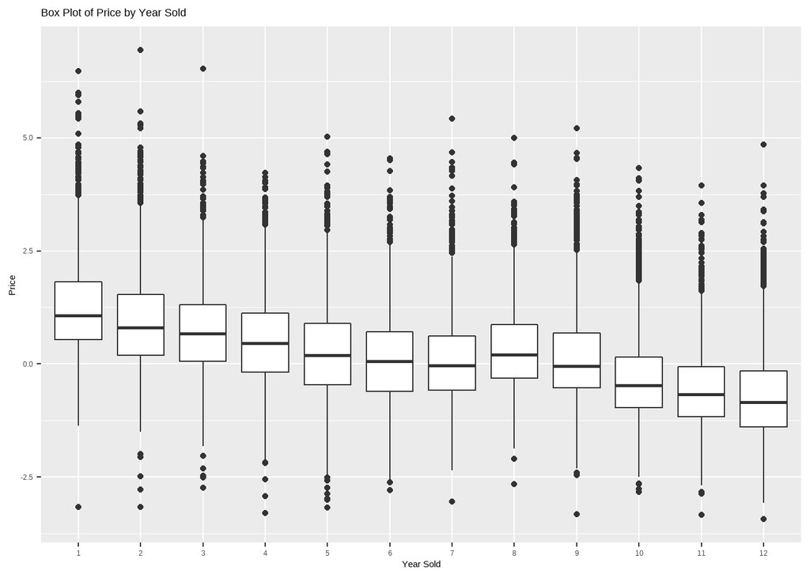

```r
ggplot(data = train) +
  geom_boxplot(mapping = aes(x = year, y = price))+ ylab("Price") +xlab("Year Sold") + ggtitle("Box Plot of Price by Year Sold")
```

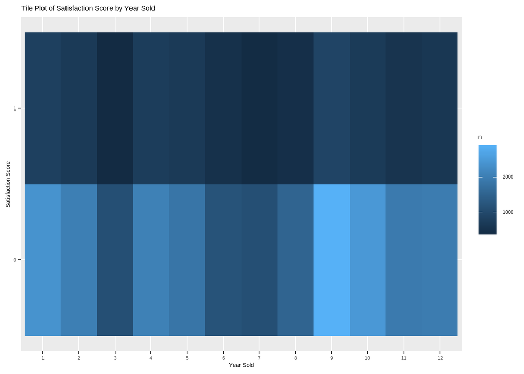

```r
#reorder(year, price, FUN = median)

train %>%
  count(sent, year) %>%
  ggplot(mapping = aes(x = year, y = sent)) +
    geom_tile(mapping = aes(fill = n)) + ylab("Satisfaction Score") +xlab("Year Sold") + ggtitle("Tile Plot of Satisfaction Score by Year Sold")
```

From the box plot, it is based on the lowest median to the highest median price, house built on the 10th decade will have the highest median price, while house built of the 4th decade will have the lowest median price.

From the tile plot, we observe that there’s significant amount of observations are not satisfied no matter what decade the house was built.

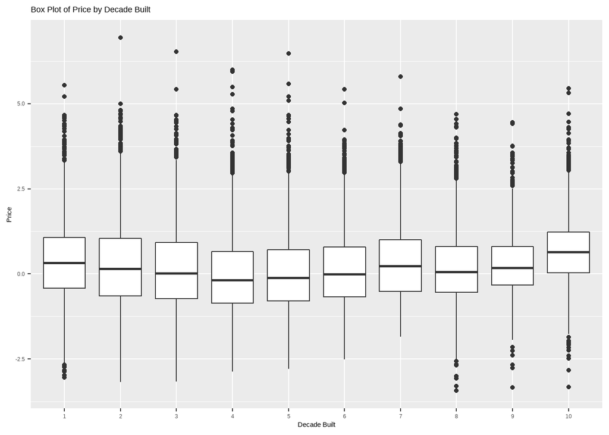

```r
ggplot(data = train) +
  geom_boxplot(mapping = aes(x = built, y = price)) + ylab("Price") +xlab("Decade Built") + ggtitle("Box Plot of Price by Decade Built")
```

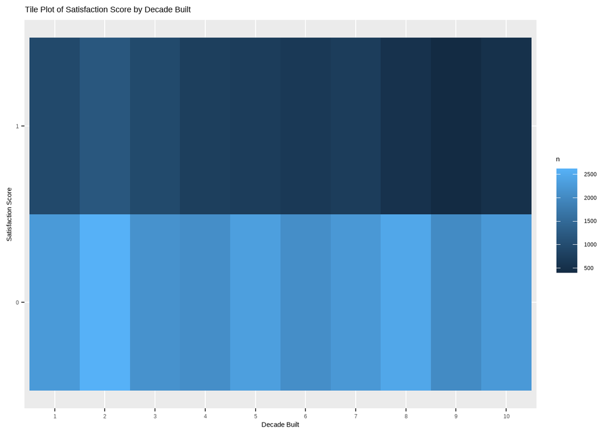

```r
train %>%
  count(sent, built) %>%
  ggplot(mapping = aes(x = built, y = sent)) +
    geom_tile(mapping = aes(fill = n)) + ylab("Satisfaction Score") +xlab("Decade Built") + ggtitle("Tile Plot of Satisfaction Score by Decade Built")
```

From the scatterplot, latitude between -1 and 1 has a strong relationship and clustered tightly. However, latitude less than -3 has a strong relationship and clustered tightly, having a significant gap from latitude between -1 and 1.

From the boxplot, latitude under -3 has outliers of both 1 and 0 satisfaction score, which is expected.

```r
coef(lm(price ~ lat, data = train))
```

```
## (Intercept)         lat
##  0.24506962  0.02301766
```

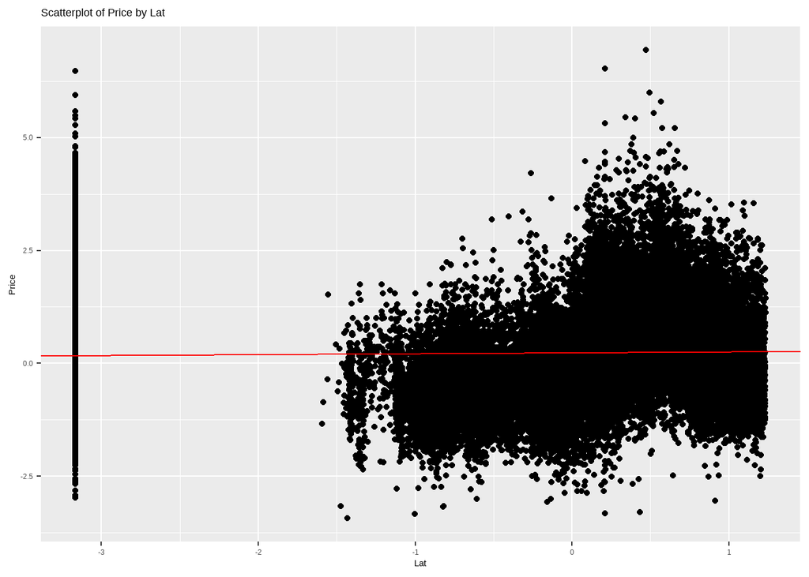

```r
ggplot(data = train) +
  geom_point(mapping = aes(x = lat, y = price)) + geom_abline(intercept = 0.24, slope = 0.02, col = "red")+ ylab("Price") +xlab("Lat") + ggtitle("Scatterplot of Price by Lat")
```

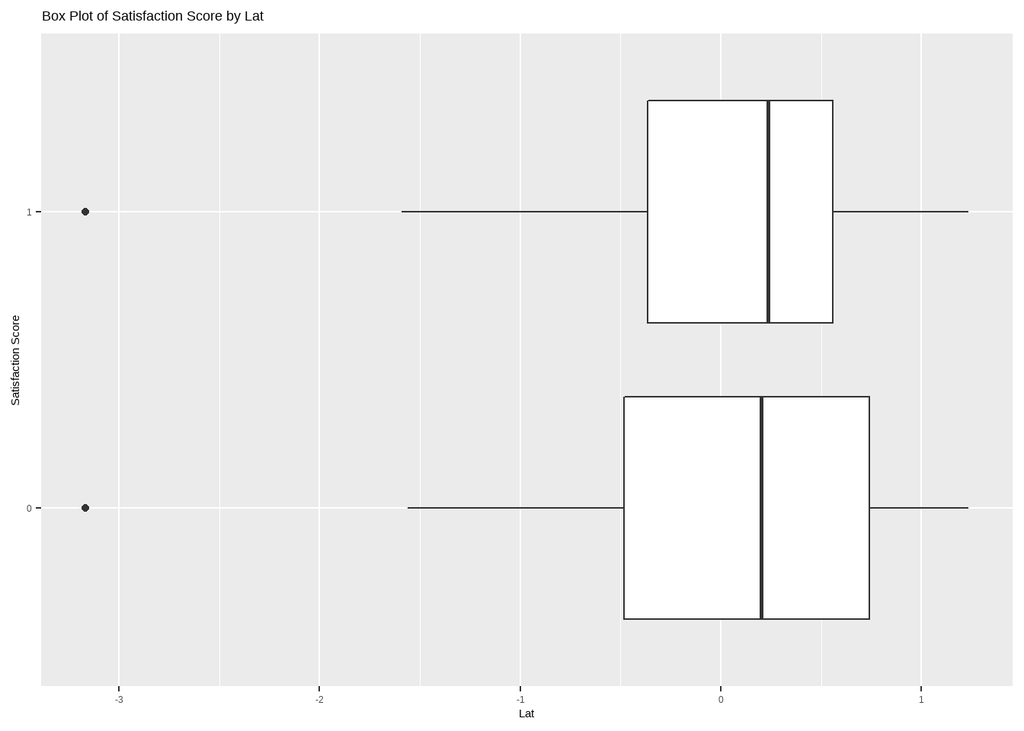

```r
ggplot(data = train, mapping = aes(x = lat, y = sent)) +
  geom_boxplot() + ylab("Satisfaction Score") +xlab("Lat") + ggtitle("Box Plot of Satisfaction Score by Lat")
```

Looking at scatterplot, longtitude has a similar plot with latitude with a significant gap from longtitude between 0 and 1. Longtitude between 0 and 1 and longtitude under -4 has a strong relationship and clustered tightly.

From the boxplot, latitude under -4 has outliers of both 1 and 0 satisfaction score, similar to the previous box plot of lat.

```r
coef(lm(price ~ lon, data = train))
```

```
## (Intercept)         lon
##   0.2305310  -0.1688007
```

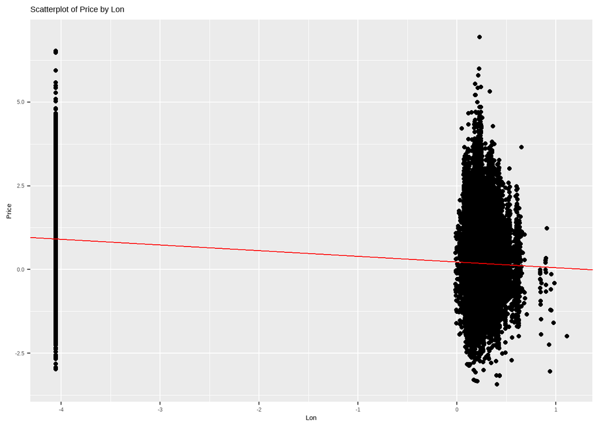

```r
ggplot(data = train) +
  geom_point(mapping = aes(x = lon, y = price)) + geom_abline(intercept = 0.23, slope = -0.17, col = "red") + ylab("Price") +xlab("Lon") + ggtitle("Scatterplot of Price by Lon")
```

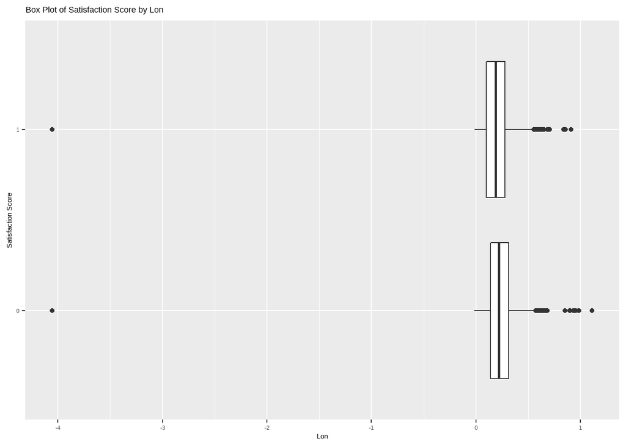

```r
ggplot(data = train, mapping = aes(x = lon, y = sent)) +
  geom_boxplot() + ylab("Satisfaction Score") +xlab("Lon") + ggtitle("Box Plot of Satisfaction Score by Lon")
```

Looking at the scatterplot, we see that square meters of living space has a positive and stronger relationship with the price of house sold at. We see also that there’s an outlier of having more than 2000 square meters of living space with price less than 5.0.

Looking at the boxplot, it could be the same outlier observation is very satisfied with their purchase of the house.

```r
coef(lm(price ~ sq.m.h, data = train))
```

```
##  (Intercept)       sq.m.h
## -1.169765675  0.006611341
```

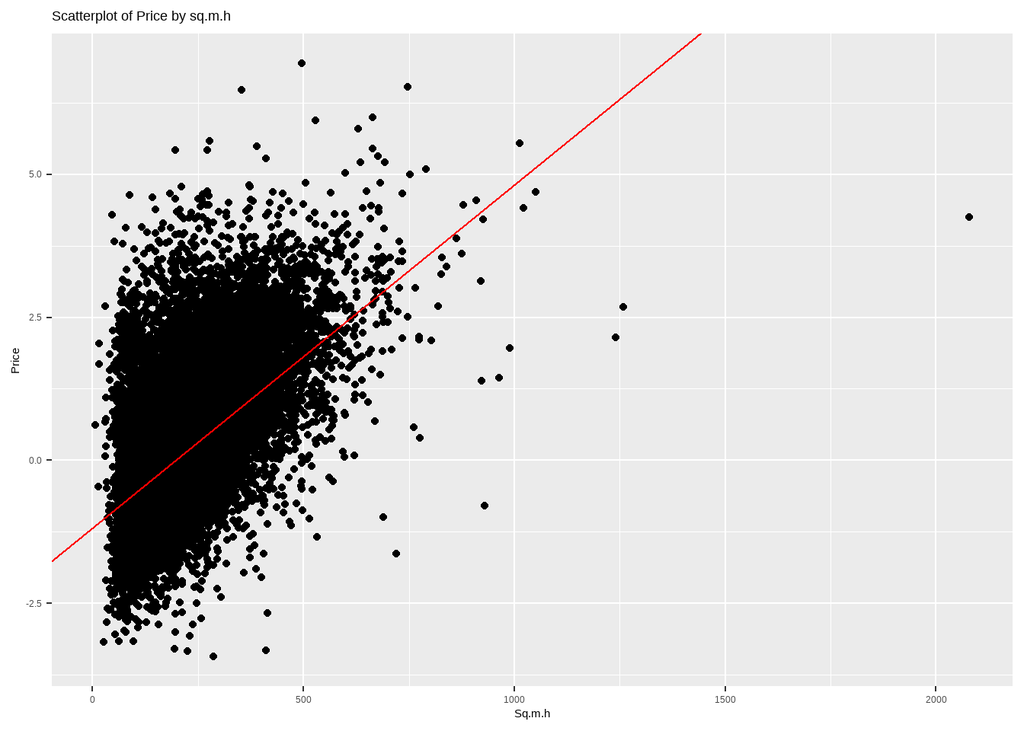

```r
ggplot(data = train) +
  geom_point(mapping = aes(x = sq.m.h, y = price)) + geom_abline(intercept = -1.17, slope = 0.006, col = "red")+ ylab("Price") +xlab("Sq.m.h") + ggtitle("Scatterplot of Price by sq.m.h")
```

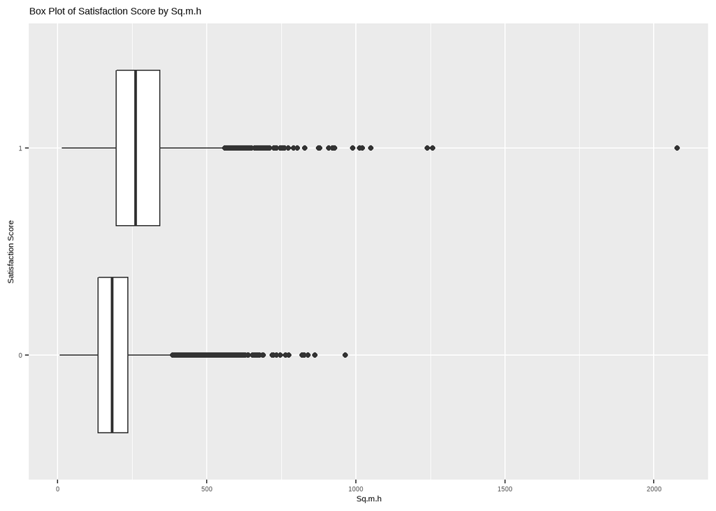

```r
ggplot(data = train, mapping = aes(x = sq.m.h, y = sent)) +
  geom_boxplot()+ ylab("Satisfaction Score") +xlab("Sq.m.h") + ggtitle("Box Plot of Satisfaction Score by Sq.m.h")
```

From the scatterplot, there’s not a positive relationship but a strong relationship between price and square meters of the lot size.

From the boxplot, there exist outliers.

```r
coef(lm(price ~ sq.m.block, data = train))
```

```
##  (Intercept)   sq.m.block
## 2.140177e-01 2.034816e-05
```

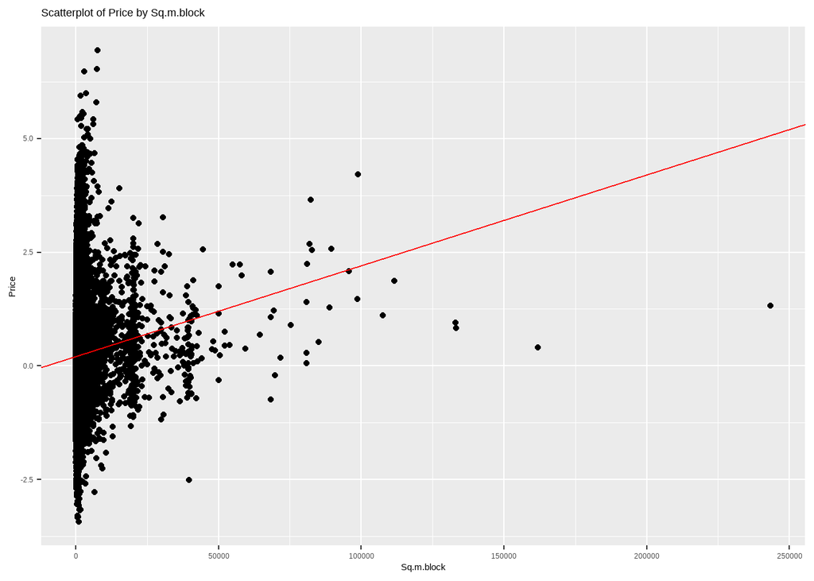

```r
ggplot(data = train) +
  geom_point(mapping = aes(x = sq.m.block, y = price)) + geom_abline(intercept = 0.21, slope = 0.00002, col = "red")+ ylab("Price") +xlab("Sq.m.block") + ggtitle("Scatterplot of Price by Sq.m.block")
```

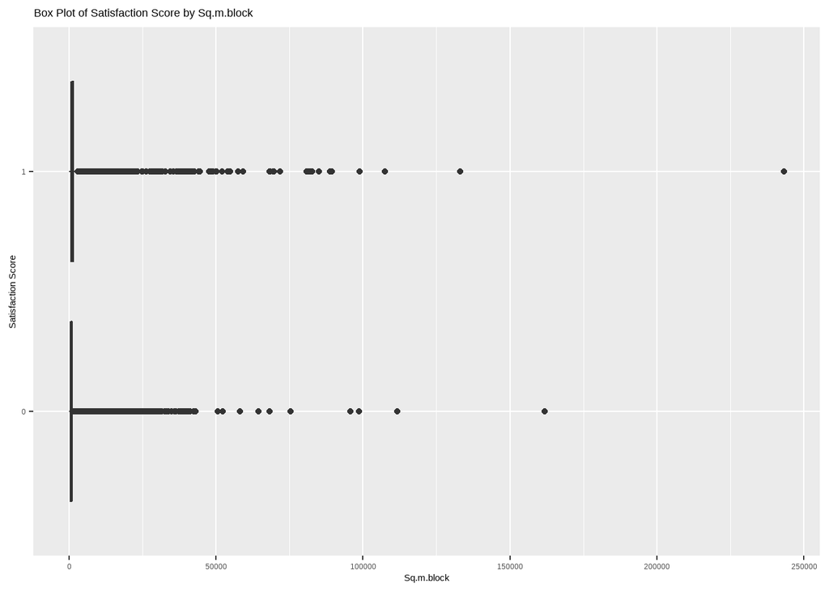

```r
ggplot(data = train, mapping = aes(x = sq.m.block, y = sent)) +
  geom_boxplot()+ ylab("Satisfaction Score") +xlab("Sq.m.block") + ggtitle("Box Plot of Satisfaction Score by Sq.m.block")
```

Observing the boxplot, the outliers could be the same as the scatterplot between square meters of the pool size and satisfaction score.

```r
coef(lm(price ~ sq.m.pool, data = train))
```

```
## (Intercept)   sq.m.pool
##  0.08382284  0.00629291
```

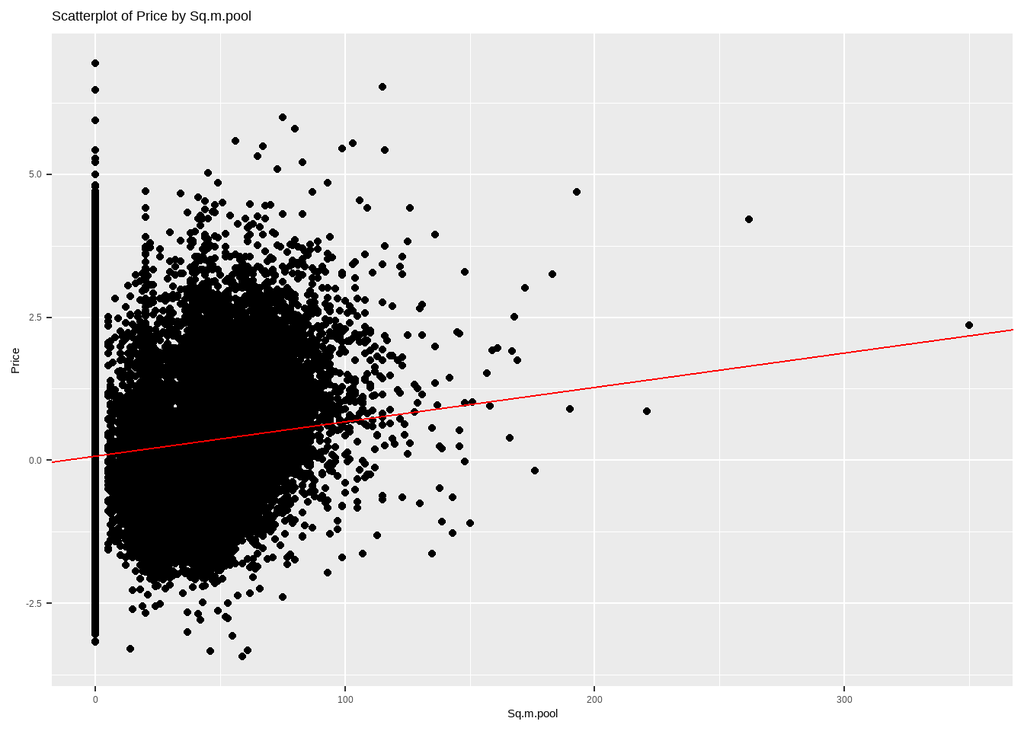

```r
ggplot(data = train) +
  geom_point(mapping = aes(x = sq.m.pool, y = price)) + geom_abline(intercept = 0.08, slope = 0.006, col = "red")+ ylab("Price") +xlab("Sq.m.pool") + ggtitle("Scatterplot of Price by Sq.m.pool")
```

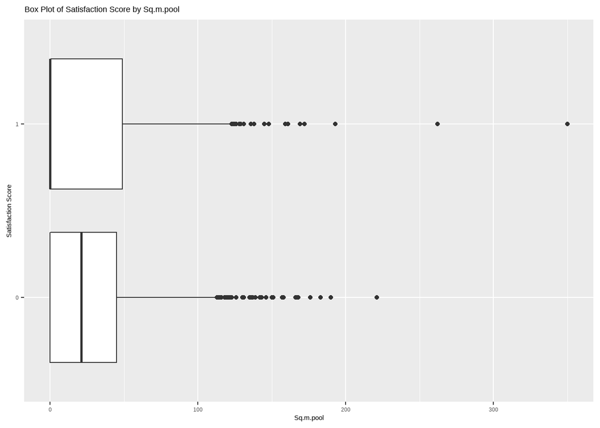

```r
ggplot(data = train, mapping = aes(x = sq.m.pool, y = sent)) +
  geom_boxplot()+ ylab("Satisfaction Score") +xlab("Sq.m.pool") + ggtitle("Box Plot of Satisfaction Score by Sq.m.pool")
```

From the box plot, reno and price seem to be normal.

Looking at the tile plot, we see that a significant amount of observations are not satisfied when the houses are not renovated.

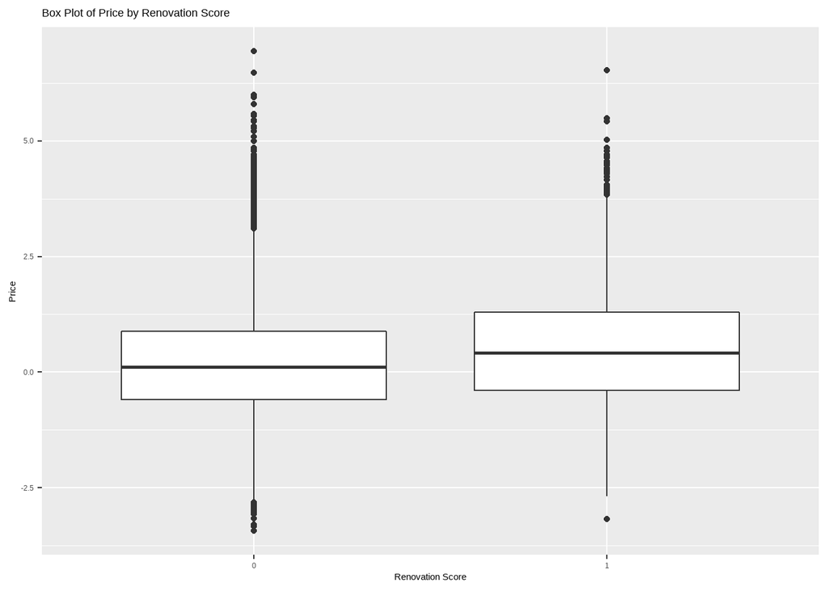

```r
ggplot(data = train) +
  geom_boxplot(mapping = aes(x = reorder(reno, price, FUN = median), y = price))+ ylab("Price") +xlab("Renovation Score") + ggtitle("Box Plot of Price by Renovation Score")
```

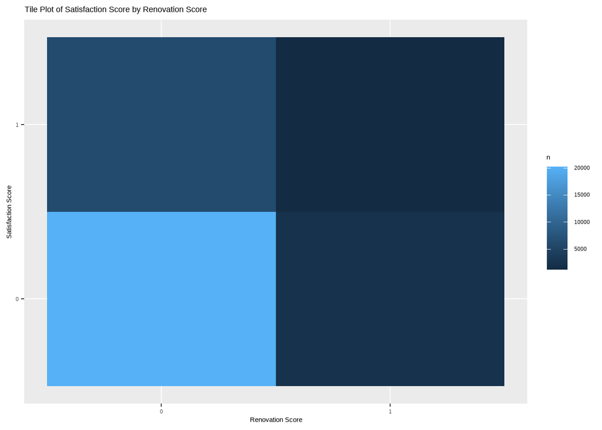

```r
train %>%
  count(sent, reno) %>%
  ggplot(mapping = aes(x = reno, y = sent)) +
    geom_tile(mapping = aes(fill = n))+ ylab("Satisfaction Score") +xlab("Renovation Score") + ggtitle("Tile Plot of Satisfaction Score by Renovation Score")
```

From the box plot, it seems that there’s an outlier between number of bedrooms and price when there are 3 bedrooms.

In the tile plot, a significant amount of observations indicating that houses with 3 to 4 bedrooms are not satisfied with the purchase.

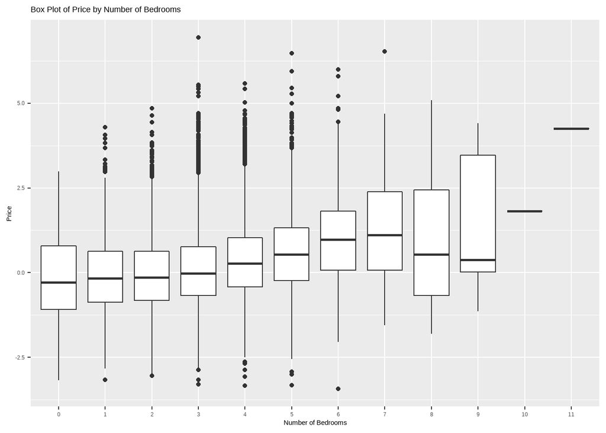

```r
ggplot(data = train) +
  geom_boxplot(mapping = aes(x = bedrooms, y = price))+ ylab("Price") +xlab("Number of Bedrooms") + ggtitle("Box Plot of Price by Number of Bedrooms")
```

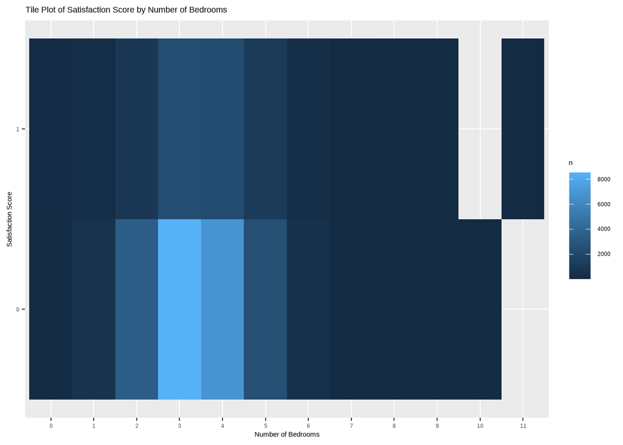

```r
train %>%
  count(sent, bedrooms) %>%
  ggplot(mapping = aes(x = bedrooms, y = sent)) +
    geom_tile(mapping = aes(fill = n)) + ylab("Satisfaction Score") +xlab("Number of Bedrooms") + ggtitle("Tile Plot of Satisfaction Score by Number of Bedrooms")
```

Observing the box plot, it seems that house with 0 bathroom exists an outlier between price and bathrooms.

Looking at the tile plot, between 1 and 3 bathrooms, significant amount of observations are not satisfied with the purchase.

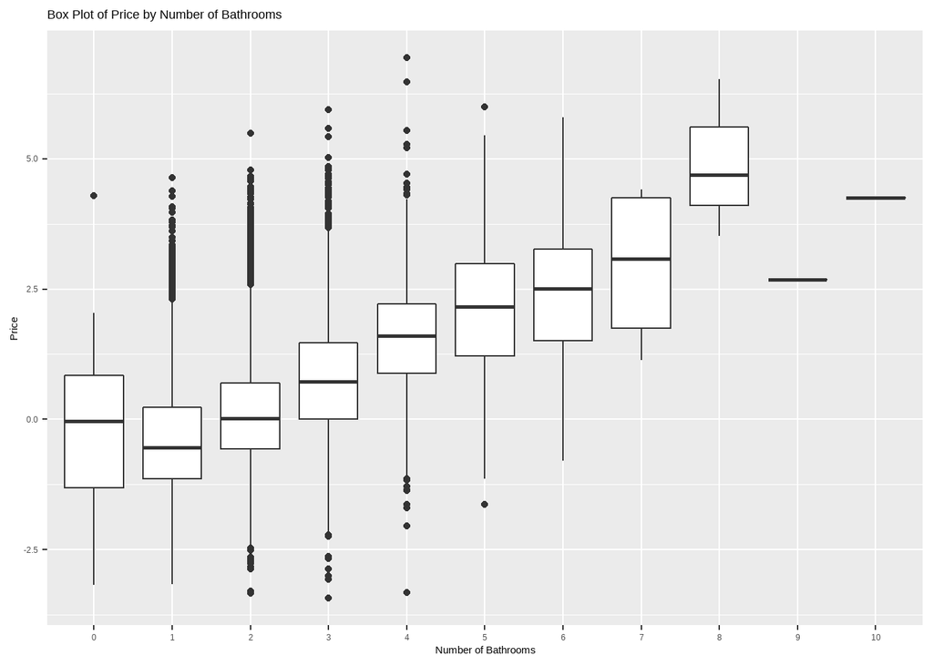

```r
ggplot(data = train) +
  geom_boxplot(mapping = aes(x = bathrooms, y = price))+ ylab("Price") +xlab("Number of Bathrooms") + ggtitle("Box Plot of Price by Number of Bathrooms")
```

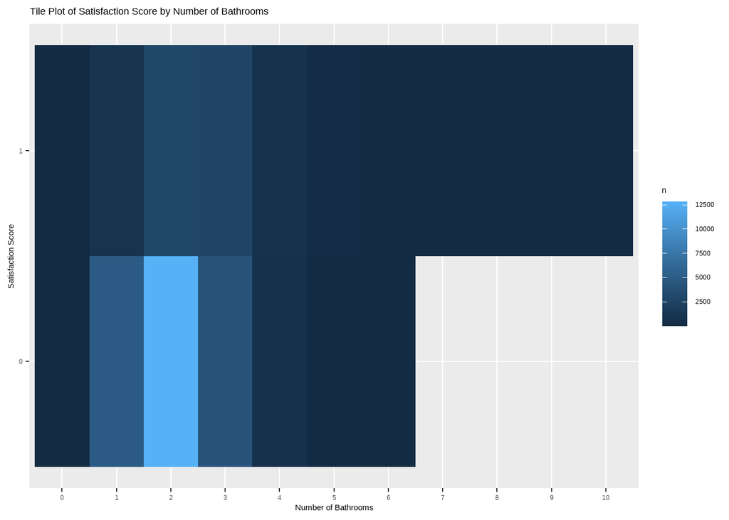

```r
train %>%
  count(sent, bathrooms) %>%
  ggplot(mapping = aes(x = bathrooms, y = sent)) +
    geom_tile(mapping = aes(fill = n)) + ylab("Satisfaction Score") +xlab("Number of Bathrooms") + ggtitle("Tile Plot of Satisfaction Score by Number of Bathrooms")
```

Looking at the box plot, it seems to be normal and there are no significant observations require further research.

In the tile plot, an environ score of 1 has a significant amount of observations that are not satisfied with the purchase.

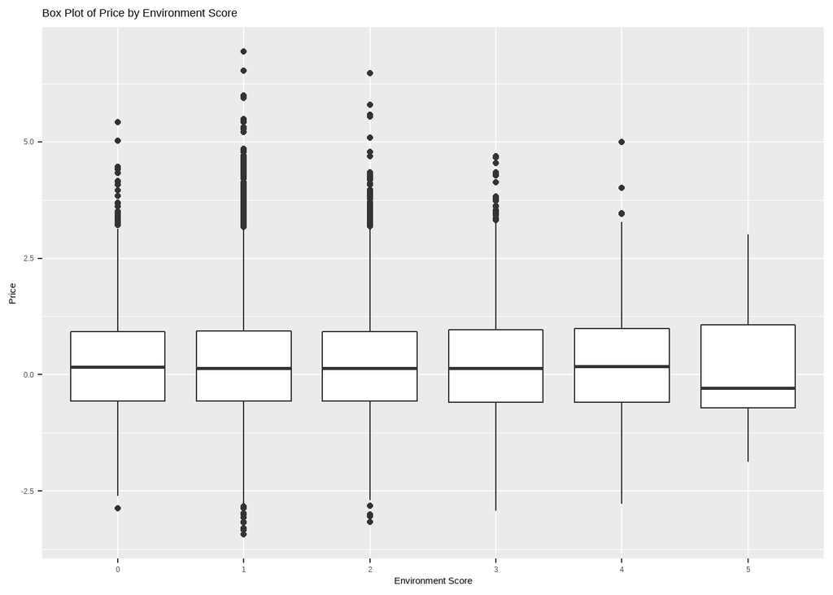

```r
ggplot(data = train) +
  geom_boxplot(mapping = aes(x = environ, y = price))+ ylab("Price") +xlab("Environment Score") + ggtitle("Box Plot of Price by Environment Score")
```

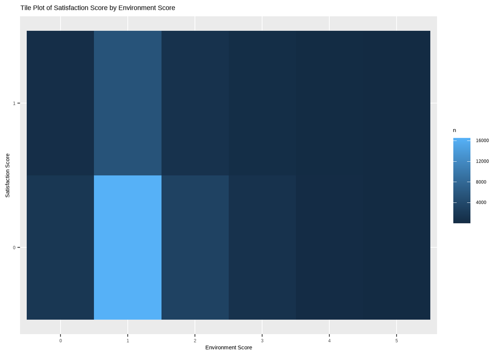

```r
train %>%
  count(sent, environ) %>%
  ggplot(mapping = aes(x = environ, y = sent)) +
    geom_tile(mapping = aes(fill = n)) + ylab("Satisfaction Score") +xlab("Environment Score") + ggtitle("Tile Plot of Satisfaction Score by Environment Score")
```

## Correlation matrix

Looking at the correlation matrix, with the method of pearson, we find that square meters of living space (sq.m.h) has a strong correlation with the price of the house sold with a value of 0.58.

[figure not shown]

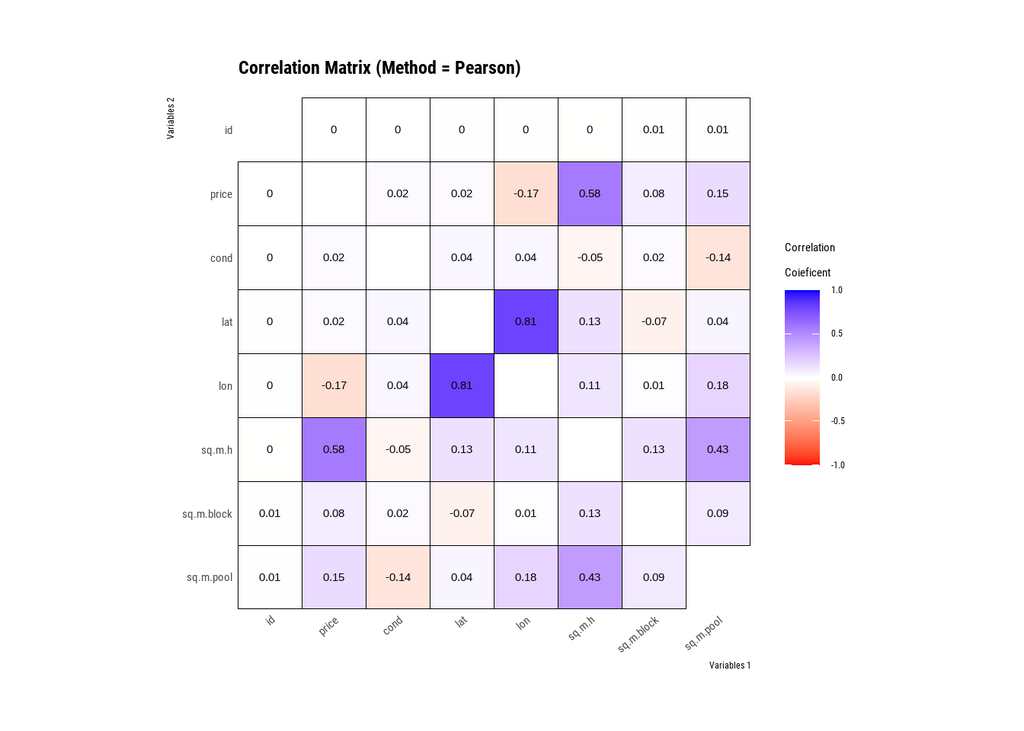

```r
train %>%
  correlate() %>%
  plot() + xlab("Variables 1") + ylab("Variables 2") + ggtitle("Correlation Matrix (Method = Pearson)")
```

## Naive Predictions

Are there more 1s than 0s for satisfaction score in the dataset?

Calculating the mode for sent, there are more 0s compared to 1s.

```r
calc_mode(train$sent)
```

```
## [1] 0
## Levels: 0 1
```

Are there more houses renovated compared to not renovated?

After calculating the mode for reno, there are more houses that are not renovated.

```r
calc_mode(train$reno)
```

```
## [1] 0
## Levels: 0 1
```

Is the price of the house sold higher when renovated?

After calculating the mean price of the house when renovated, it is higher than houses that are not renovated.

```r
mean(train[train$reno == '0', 'price'])
```

```
## [1] 0.2091988
```

```r
mean(train[train$reno == '1', 'price'])
```

```
## [1] 0.503839
```

## 3. Modelling Component 1

First model: Multiple regression with backward selection method to select the best predictors

Backward selection method is chosen because forward selection method because of the so-called suppressor effects produced by the forward selection technique. Predictors are only significant when another predictor is maintained constant therefore these suppressor effects occur.

With backward selection method, the best predictors for multiple regression include cond, year, built, lat, lon, sq.m.h, sq.m.block, sq.m.pool, bedrooms and bathrooms. Looking at step.model, sent can be disregarded as it is a dependent variable in this report. After removing sent, environ p-value is significantly more than 0.05, therefore can be disregarded as well.

```r
# Fit the full model
full.model <- lm(price ~., data = train)
# Stepwise regression model
step.model <- stepAIC(full.model, direction = "backward",
                      trace = FALSE)
anova(step.model)
```

|  | Df | Sum Sq | Mean Sq | F value | Pr(>F) |
| --- | --- | --- | --- | --- | --- |
| sent | 1 | 8222.104381 | 8222.104381 | 24864.907084 | 0.000000e+00 |
| cond | 1 | 6.895629 | 6.895629 | 20.853443 | 4.977728e-06 |
| year | 11 | 9614.744677 | 874.067698 | 2643.315031 | 0.000000e+00 |
| built | 9 | 780.030514 | 86.670057 | 262.103571 | 0.000000e+00 |
| lat | 1 | 139.540759 | 139.540759 | 421.992697 | 3.947967e-93 |
| lon | 1 | 3513.057984 | 3513.057984 | 10624.027172 | 0.000000e+00 |
| sq.m.h | 1 | 6473.161109 | 6473.161109 | 19575.833880 | 0.000000e+00 |
| sq.m.block | 1 | 17.115237 | 17.115237 | 51.759107 | 6.421751e-13 |
| sq.m.pool | 1 | 57.467145 | 57.467145 | 173.789477 | 1.418702e-39 |
| bedrooms | 11 | 82.457231 | 7.496112 | 22.669394 | 6.135875e-47 |

[output cut: 3 more lines]

```r
mr <- lm(price ~ cond + year + built + lat + lon + sq.m.h + sq.m.block + sq.m.pool + bedrooms + bathrooms, data = train)
anova(mr)
```

|  | Df | Sum Sq | Mean Sq | F value | Pr(>F) |
| --- | --- | --- | --- | --- | --- |
| cond | 1 | 17.356988 | 1.735699e+01 | 45.18199 | 1.827677e-11 |
| year | 11 | 9926.834687 | 9.024395e+02 | 2349.14089 | 0.000000e+00 |
| built | 9 | 610.854425 | 6.787271e+01 | 176.67951 | 0.000000e+00 |
| lat | 1 | 19.347974 | 1.934797e+01 | 50.36472 | 1.305059e-12 |
| lon | 1 | 4614.052233 | 4.614052e+03 | 12010.84236 | 0.000000e+00 |
| sq.m.h | 1 | 11825.389772 | 1.182539e+04 | 30782.67978 | 0.000000e+00 |
| sq.m.block | 1 | 34.866024 | 3.486602e+01 | 90.75977 | 1.740012e-21 |
| sq.m.pool | 1 | 9.954253 | 9.954253e+00 | 25.91192 | 3.595153e-07 |
| bedrooms | 11 | 175.292218 | 1.593566e+01 | 41.48212 | 3.425500e-90 |
| bathrooms | 9 | 194.327726 | 2.159197e+01 | 56.20607 | 2.499978e-102 |

[output cut: 1 more lines]

```r
#Randomly shuffle the data
yourData<-train[sample(nrow(train)),]

#Create 10 equally size folds
folds <- cut(seq(1,nrow(train)),breaks=10,labels=FALSE)

set.seed(1)
#Perform 10 fold cross validation
for(i in 1:10){

    testIndexes <- which(folds==i,arr.ind=TRUE)
    testData <- train[testIndexes, ]
    trainData <- train[-testIndexes, ]

    model <- glm(price ~ cond + year + built + lat + lon + sq.m.h + sq.m.block + sq.m.pool + as.numeric(bedrooms) + as.numeric(bathrooms) + environ, data = trainData)
    pred.test.glm <- predict(model, newdata = testData)
    mse.out <- mean((testData$price - pred.test.glm)^2, na.rm = TRUE)
}
mse.out
```

```
## [1] 0.3673352
```

Third Model: Lasso Regression with 10-fold cross validation

Using alpha = 1 to fit lasso regression model. 10-fold cross validation method was used to find the best lambda value.

Looking at best.model.lasso, no coefficient is shown for the predictor environ. This means that environ is completely dropped from the model because it wasn’t influential enough.

Mean Squared Error for this model is 0.4274.

```r
library(glmnet)

y.lasso <- train$price

x.lasso <- data.matrix(train[,c('cond','year','built','lat','lon','sq.m.h','sq.m.block','sq.m.pool','reno','bedrooms','bathrooms','environ')])

cv.model.lasso <- cv.glmnet(x.lasso, y.lasso, alpha = 1)

best.lambda.lasso <- cv.model.lasso$lambda.min
best.lambda.lasso
```

```
## [1] 0.001287221
```

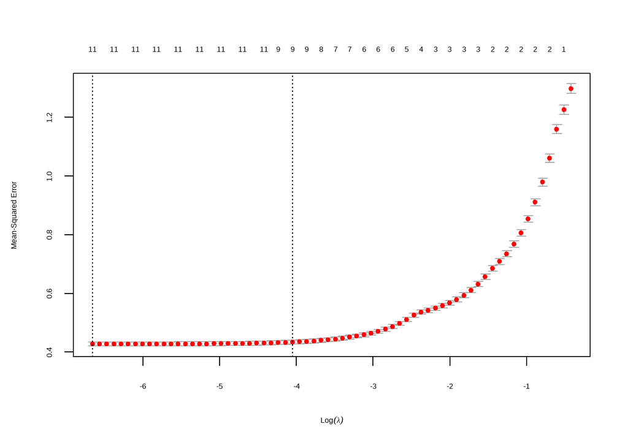

```r
plot(cv.model.lasso)
```

```r
best.model.lasso <- glmnet(x.lasso, y.lasso, alpha = 1,lambda = best.lambda.lasso)
coef(best.model.lasso)
```

```
## 13 x 1 sparse Matrix of class "dgCMatrix"
##                        s0
## (Intercept) -1.626015e-01
## cond         2.191827e-02
## year        -1.492657e-01
## built       -1.926161e-02
## lat          4.112898e-01
## lon         -5.340585e-01
## sq.m.h       6.349427e-03
## sq.m.block   6.758345e-06
## sq.m.pool    1.025915e-03
## reno         2.913286e-02
## bedrooms    -6.429561e-02
## bathrooms    1.047535e-01
## environ      .
```

```r
y.predicted.lasso <- predict(best.model.lasso, s = best.lambda.lasso, newx = x.lasso)

mse.lasso <- mean((y.lasso - y.predicted.lasso)^2)
mse.lasso
```

```
## [1] 0.4273711
```

Fourth Model: Ridge Regression with 10 fold cross validation

Using alpha = 0 to fit ridge regression model. 10-fold cross validation method was used to find the best lambda value.

From this model, we see that sq.m.block is the least influential predictor in this model as it is the smallest value from coef(best.model.ridge).

Mean Squared Error for this model is 0.4359.

```r
library(glmnet)
y.ridge <- train$price

x.ridge <- data.matrix(train[,c('cond','year','built','lat','lon','sq.m.h','sq.m.block','sq.m.pool','reno','bedrooms','bathrooms','environ')])

model.ridge <- glmnet(x.ridge, y.ridge, alpha = 0)
summary(model.ridge)
```

```
##           Length Class     Mode
## a0         100   -none-    numeric
## beta      1200   dgCMatrix S4
## df         100   -none-    numeric
## dim          2   -none-    numeric
## lambda     100   -none-    numeric
## dev.ratio  100   -none-    numeric
## nulldev      1   -none-    numeric
## npasses      1   -none-    numeric
## jerr         1   -none-    numeric
## offset       1   -none-    logical
## call         4   -none-    call
## nobs         1   -none-    numeric
```

```r
cv.model.ridge <- cv.glmnet(x.ridge, y.ridge, alpha = 0)

best.lambda.ridge <- cv.model.ridge$lambda.min
best.lambda.ridge
```

```
## [1] 0.06557281
```

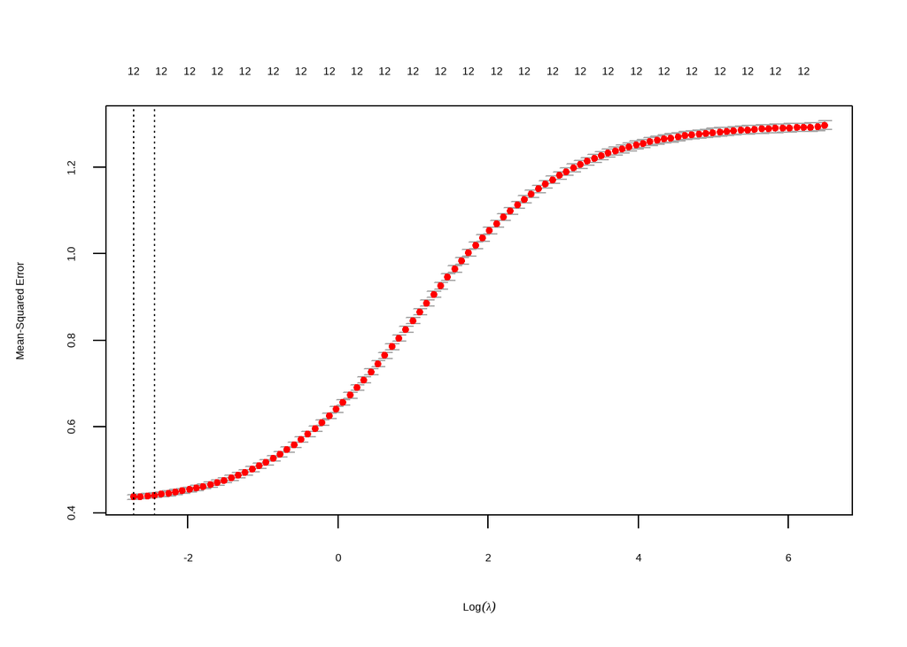

```r
plot(cv.model.ridge)
```

```r
best.model.ridge <- glmnet(x.ridge, y.ridge, alpha = 0, lambda = best.lambda.ridge)
coef(best.model.ridge)
```

```
## 13 x 1 sparse Matrix of class "dgCMatrix"
##                        s0
## (Intercept) -2.852261e-01
## cond         1.700912e-02
## year        -1.412251e-01
## built       -2.332211e-02
## lat          3.036680e-01
## lon         -4.244523e-01
## sq.m.h       5.771733e-03
## sq.m.block   5.911469e-06
## sq.m.pool    9.550063e-04
## reno         4.875670e-02
## bedrooms    -5.255336e-02
## bathrooms    1.482189e-01
## environ      4.690769e-03
```

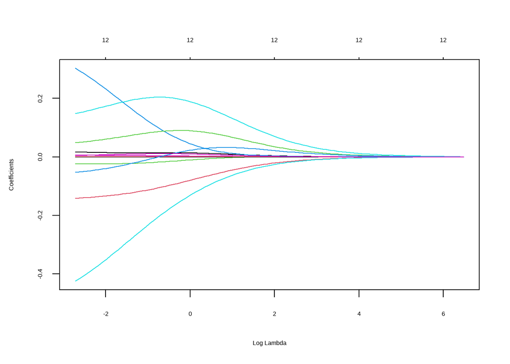

```r
plot(model.ridge, xvar = "lambda")
```

```r
y.predicted.ridge <- predict(best.model.ridge, s = best.lambda.ridge, newx = x.ridge)

mse.ridge <- mean((y.ridge - y.predicted.ridge)^2)
mse.ridge
```

```
## [1] 0.4358645
```

Fifth Model: Principal Components Regression with 10-fold cross validation